# ST Neural-ART NPU - Runtime loadable model support

3.0.0  
ST Neural-ART NPU - Runtime loadable model support

- Introduction
  - What is a runtime loadable model?
  - Solution overview
    - Memory model
    - Limitations
    - Embedded compiler options for relocatable mode
  - Prerequisites - Setting up a work environment
- Getting started
  - Generating a runtime loadable model
    - NPU compiler and CLI options
    - Relocatable options
    - Memory layout information
  - Epoch controller consideration
  - Weights/params encryption consideration
  - Format of the relocatable binary model
- Evaluating the RT loadable model (STM32N6570-DK board)
  - Supported features/limitations
  - Deploy a model
  - Evaluate the model
  - Deploy multiple models
- Deploy and use a relocatable model
  - LL_ATON stack configuration
  - Minimal code
  - XIP/COPY execution modes
    - XIP execution mode
    - COPY execution mode
  - Example of NPU compiler configuration files
    - Memory-pool descriptor files
    - “neural_art.json” file
- Performance impacts
  - Accuracy
  - Set up and inference time
  - Memory layout overhead
- LL ATON runtime API extension
  - ll_aton_reloc_install()
    - *ll_aton_reloc_config* C-struct
  - ll_aton_reloc_set_callbacks()
  - ll_aton_reloc_get_info()
    - *ll_aton_reloc_info* C-struct
  - ll_aton_reloc_get_mem_pool_desc()
    - *ll_aton_reloc_mem_pool_desc* C-struct
  - ll_aton_reloc_get_input/output_buffers_info()
  - ll_aton_reloc_set_input/output()
  - ll_aton_reloc_get_input/output()
- Use directly the Python scripts
  - Generating the relocatable binary model
    - “–name/-n” option

# ST Neural-ART NPU - Runtime loadable model support

for STM32 target, based on ST Edge AI Core Technology 3.0.0

r1.3

- STM32N6 with Neural-ART accelerator™

# Introduction

## What is a runtime loadable model?

A runtime loadable model, also known as a relocatable binary model, is a binary object that can be installed and executed at runtime within an STM32 memory subsystem. This model includes a compiled version of the generated neural network (NN) C files, encompassing the necessary forward kernel functions and weights/parameters. Its primary purpose is to offer a flexible method for upgrading AI-based applications without the need to regenerate and flash the entire end-user firmware. This approach is particularly useful for technologies such as firmware over-the-air (FOTA). This feature allows the following:

- Models and their associated memory contents to be loaded dynamically at runtime.
- Flexibility to update or swap models without rebuilding the entire application.
- Clear separation between application logic and model data.

The binary object can be seen as a lightweight plug-in, capable of running from any address (position-independent code) and storing its data anywhere in memory (position-independent data). An efficient and minimal dynamic/runtime loader enables the instantiation and usage of this model. Unlike traditional systems, the firmware does not embed a complex and resource-intensive dynamic linker for Arm® Cortex®-M microcontrollers. The generated object is mainly self-contained, requiring limited and well-defined external symbols (NPU runtime dependent) at runtime.

In comparison with the software-only solution (fully self-contained object), the runtime loadable model for the Neural-ART accelerator must be installed inside an NPU runtime software stack. This allows supporting multiple instances, including the static version. No specific synchronization mechanism is embedded in the relocatable part; instead, the scheduling and access to the hardware resources (NPU subsystem) are managed by the stack itself (static part).

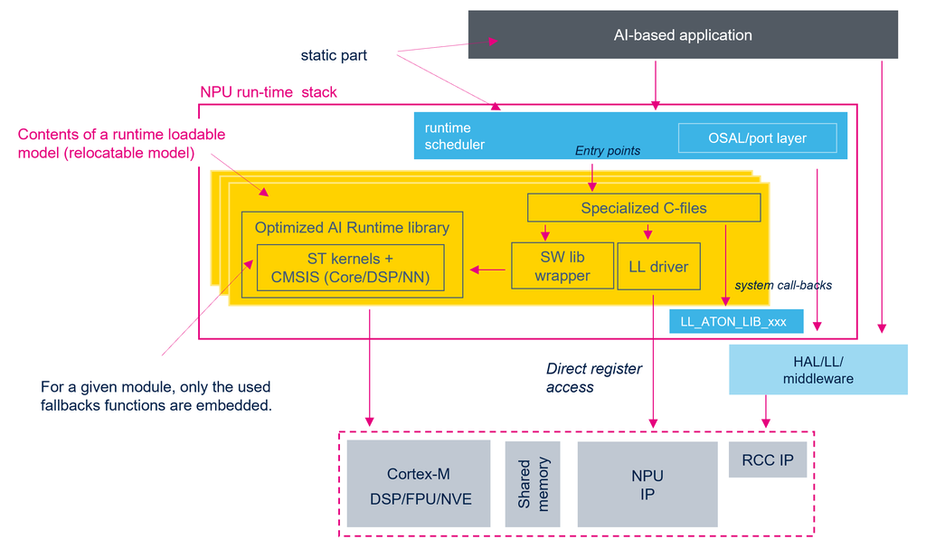

NPU stack with runtime loadable models

The generated runtime loadable model is a container that includes relocatable code (text, data, and rodata sections) to configure various neural processing unit (NPU) epochs. It primarily comprises a compiled version (microcontroller unit (MCU)-dependent) of the specialized `network.c` file, the low-level (LL) ATON driver functions used, and the code for delegated software operations, which are part of the optimized network runtime library. For hybrid epochs (calls to `LL_ATON_LIB_xxx` functions), a specific callback-based mechanism is implemented to directly invoke the services of the stack. These system callback functions are provided by the static part of the NPU stack and are registered during the installation phase of the model (see the ll_aton_reloc_install() function).

## Solution overview

### Memory model

As illustrated in the following figure, to use runtime loadable models, a portion of the internal RAMs (read/write AI regions) is fixed or reserved and has absolute addresses. These regions must not be used by the application during inference. A non-fixed *executable RAM region* is required to install a given model. This read/write region allows to resolve the relocatable references during the installation process at runtime.

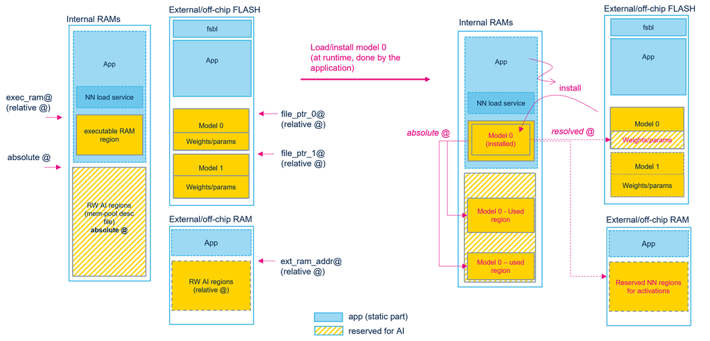

Platform memory layout

| Item | Definition |
| --- | --- |
| executable RAM region | Designates the memory region used to install a model at runtime (txt/data sections). This shared memory-mapped region, located **anywhere** in the memory subsystem, can be reserved at runtime by the a… |
| RW AI regions | Designates the memory regions which are reserved for the activations/parameters. Base addresses are **absolutes** and are defined in the mem-pool descriptor files. Attributes: MCU/NPU memory-mapped, M… |
| RW AI region (external RAM) | If requested, designates the memory regions which are allocated/reserved to place the requested part of the memory-pool defined for the external RAM. The base address can be **relative** (can be place… |
| Model X (weights/params) | Designates the memory regions where the relocatable binary models are stored. Base addresses (*file_ptr*) are **relative** and dependent on the application managing the FOTA-like mechanism. Attributes… |
| App | Designates the memory regions which are reserved for the application (static part), it embeds a minimal part (NN load service) allowing to load/install and execute a relocatable model. |

**(*)** This region must be also accessible by the NPU in the case where the epoch controller is enabled.  
**(**)** These regions should be also accessible by the MCU in the case where a operator/epoch is delegated on the MCU.

### Limitations

- Only the [STM32N6-based](https://www.st.com/en/microcontrollers-microprocessors/stm32n6-series.html) series with Neural-ART accelerator is supported.
- Addresses of the used internal/on-chip memory-pools are fixed/absolutes (USEMODE_ABSOLUTE attribute). *Only* the external addresses relative to the off-chip memories: flash and RAM type, can be relocatable/relative (or USEMODE_RELATIVE attribute)
- Only two relocatable/relative memory pools are supported. One for RO regions handling the weights/params and another for an external RW memory region. Note that the external RAM region can be also absolute.
- Secure mode generation and [XIP mode][ref_rel_xip_mode] are not supported with ARM clang/llvm toolchain (cmse is not compatible with ROPI/RWPI).
- Support for the encrypted weights/params throught the ST Edge AI core CLI is not supported.

### Embedded compiler options for relocatable mode

To generate relocatable objects, according to the Arm® Embedded toolchain used, two sets of compilation options are considered (see makefiles from the `$STEDGEAI_CORE_DIR/scripts/N6_reloc/resources` folder):

- For a **GCC Arm® Embedded toolchain**, all the code, including the network runtime library, is compiled using the *-fpic*, *-msingle-pic-base*, and *-mno-pic-data-is-text-relative* options. The Arm® Cortex®-M *r9* register is designated as the platform register for the global offset table (GOT). The primary task of the dynamic/runtime loader is to update the GOT table and the indirect references in the data structure. Both XIP & COPY modes are fully supported.
- For a **CLANG/LLVM Arm® Embedded toolchain**, all the code is compiled with the options *-fropi* and *-frwpi*. The *r9* register is also used; however, some constant/text parts must also be updated by the dynamic/runtime loader, which does not allow support for the XIP mode.

## Prerequisites - Setting up a work environment

The generation of a runtime-loadable model is integrated into the ST Edge AI Core command-line interface (CLI). A specific pass calls the dedicated Python scripts located in the `$STEDGEAI_CORE_DIR/scripts/N6_reloc` directory. The `npu_driver.py` script acts as the entry point for generating the runtime-loadable models, which can be used directly. By default, a [GNU Arm Embedded tool-chain](https://developer.arm.com/tools-and-software/open-source-software/developer-tools/gnu-toolchain/gnu-rm) supporting the Arm® Cortex® M55 (with the ‘arm-none-eabi-’ prefix) is used. The user must ensure that the executable is available in the PATH, including a Make utility. The custom option allows to customize the enviroment.

> `%STEDGEAI_CORE_DIR%` represents the root location where the ST Edge AI Core components are installed, typically in a path like `"<tools_dir>/STEdgeAI/<version>/"`.

**Using the Python scripts directly**

To use the scripts directly, a Python 3.9+ and the following Python modules are requested:

```
pyelftools==0.27
tabulate
colorama
```

Note

The Python interpreter available in the ST Edge AI Core pack can be directly used (all requested Python module are already installed).

**Optional tools for built-in validation workflow**

For validating a runtime loadable model on the [STM32N6570-DK](https://www.st.com/en/evaluation-tools/stm32n6570-dk.html) board, you may optionally install:

- [STM32CubeIDE](https://www.st.com/en/development-tools/stm32cubeide.html) supporting the STM32n6 series (version 1.17.0 or higher)
- stm_ai_runner Python package

**Note:** `'STM32_CUBE_IDE_DIR'` system environment variable must be set to indicate the installation folder fo the STM32CubeIDE pack.

# Getting started

## Generating a runtime loadable model

The `-r/--reloc/--relocatable [rel-option]` option allows to generate the runtime-loadable model. The standard generating workflow is extended with the additional steps to pre-process and compile the specialized c-files.

[figure not shown]

Generation of the runtime loadable model

Here is a typical output log example that you might see when running the generate command for an NPU model deployment.

```bash
$ stedgeai generate -m <model-name>.tflite/onnx --target stm32n6 --st-neural-art <profile>@<usr_neural_art_reloc>.json --reloc
 ST Edge AI Core v3.0.0
...
 Neural ART - Package for runtime loadable model - v 1.4.0
...
 Generated files (8)
 --------------------------------------------------------------------------------
 <output-directory-path>\<model-name>_OE_3_3_1.onnx
 <output-directory-path>\<model-name>_OE_3_3_1_Q.onnx
 <output-directory-path>\network.c
 <output-directory-path>\network.h
 <output-directory-path>\network_atonbuf.xSPI2.raw
 <output-directory-path>\network_c_info.json
 <output-directory-path>\network_rel.bin
 <output-directory-path>\network_generate_rel.json

Creating report file <output-directory-path>\network_generate_report.txt
```

#### Generated files

| file | description |
| --- | --- |
| `<network>_rel.bin` | The main binary file contains the compiled version of the model, including the forward kernel functions and weights by default. It also embeds additional sections (.header, .got, .rel) to enable the i… |
| `<network>_data.bin` | *Optional file*. If the split parameter is used, the weights are generated in a separated binary file. |
| `<network>_generate_rel.json` | Extra report file containing the main informations of the generated runtime loadable model (JSON format) |

**Note** that the memory initializers for the memory regions which are only used for the activations are not requested.

### NPU compiler and CLI options

There are **no restrictions** on the NPU compiler options used for this step, except for the usage of the `--all-buffers-info` option, which provides detailed information about the intermediate and activation buffers. Note that this additional information is removed during the generation of the runtime loadable model. For the memory-pool descriptor file, the following attributes are **mandatory**:

- “mode”: “USEMODE_RELATIVE” for external memory pools only. This is mandatory for the external flash part and optional for the external RAM part. Otherwise, use *“USEMODE_ABSOLUTE”*.
- “fformat”: “FORMAT_RAW” for all memory initializers.

### Relocatable options

The -r/--reloc/--relocatable option can be used with the following parameters. These parameters are mainly forwarded to specialized Python scripts.

| parameter | description |
| --- | --- |
| <none> | *Default behavior.* Generates a **single model binary file** containing network, kernels, and weights. |
| “split” | Generates **two separate binary files**: one with the model (network + kernels) and another containing **only the weights**. Useful for flexible memory management. |
| “gen-c-file” | Generates the binary file as a **C array** instead of a raw binary. Mainly for *debugging purposes*. |
| “st-clang” | Use the **ST Arm Clang toolchain** for compilation instead of the default ARM GCC based toolchain. |
| “llvm” | Use the **LLVM toolchain** for compilation instead of the default ARM GCC based toolchain. |
| “ecblob-in-params” | Places the **ecblobs (epoch controller blobs)** together with the model weights/parameters in the binary. |
| “no-secure” | Compile the binary with **non-secure flags**, useful for non-secure execution environments. Forced behavior with llvm-clang compiler. |
| “no-dbg-info” | The LL_ATON_EB_DBG_INFO C-define is not set during the compilation of the model allowing to avoid to embed the debug only information. |
| “custom[=<usr-file>.json]” | Use a **custom JSON configuration file** to override default environment settings. If no file is specified, uses `custom.json` by default. |

The parameters can be combined using a comma separator.

```bash
$ stedgeai generate -m -m <model-name>.tflite/onnx <gen_options> ---target stm32n6 -st-neural-art ... --reloc split,gen-c-file
 ...
 <output-directory-path>\network_rel.bin
 <output-directory-path>\network_data.bin
 <output-directory-path>\network_img_rel.c
 <output-directory-path>\network_img_rel.h
```

#### “split” parameter

The `split` option allows generating two separate files. In this case, to deploy the model, both files should be deployed on the target, and the address of the `"network_rel_params.bin"` should be passed during the installation process at runtime (see ll_aton_reloc_install() function).

#### “ecblob-in-params” parameter

The `ecblob-in-params` option indicates that the ecblobs are stored with the params/weights. This feature allows to reduce the requested exec memory region to execute the model in COPY mode (see *“Epoch controller consideration”* section). Ecblobs are placed at the beginning of the params/weights memory segment. The split option is always supported, the params file includes the ecblobs.

#### “no-dbg-info” parameter

The `no-dbg-info` option allows the removal of the `LL_ATON_EB_DBG_INFO` C-define to generate the runtime loadable model. This option removes debug information, including the intermediate description of buffers and additional debug fields in the epoch descriptor, thereby reducing the size of the final binary. These debug details are mandatory for using the built-in validation stack.

#### “custom” parameter

The `custom` option allows overriding certain default environment variables used to build the relocatable binary model. By default a `custom.json` file from the current working directory is used to retrieve the expected values. Alternatively, the parameter can be extended with a specific file name (for example: `--reloc cutsom=myconfog.json`).

| supported key | description |
| --- | --- |
| “runtime_network_lib” | Used to indicate the absolute path of the used network runtime library (default: *%STEDGEAI_CORE_DIR%/Middlewares/ST/AI/Lib/GCC/ARMCortexM55/NetworkRuntime1100_CM55_GCC_PIC.a* ) |
| “extra_system_path” | Used to prefix the system path allowing to retrieve the used ARM compiler. By default, the *arm-none-eabi-gcc* executable is used from the PATH |
| “llvm_install_path” | *llvm* target only. Used to set the `LLVM_COMPILER_PATH` value in the llvm makefile to indicate the root directory of the tools chain. *Mandatory* for the llvm target. |
| “target_triplet” | *llvm* target only. Set the `TARGET_TRIPLET` value in the llvm makefile. Default: `thumbv8m.main-unknown-none-eabihf` |
| “llvm_sysroot” | *llvm* target only. Set the `LLVM_SYSROOT` value in the llvm makefile. Default: `${LLVM_COMPILER_PATH}/lib/clang-runtimes/newlib/arm-none-eabi/armv8m.main_hard_fp` |

### Memory layout information

Below information is reported in the log and also in a well-formatted file in JSON format: `<network>_generate_rel.json`.

```bash
 ...
 Runtime Loadable Model - Memory Layout (series="stm32n6npu")
 --------------------------------------------------------------------------------
 v8.0 dbg=True async=True sec=True 'Embedded ARM GCC' cpuid=D22 fpu=True float-abi=2

 XIP size             = 3,344      data(2620)+got(708)+bss(16) sections
 COPY size            = 32,544     +ro(29200) sections
 extra sections       = 1,112      got:708(21.2%) header+rel:404(1.4%)
 params size          = 25,713
 acts size            = 56,496
 binary file size     = 32,832
 params file size     = 25,720

 +--------------------------+----------------------------------+------+------------+-------+
 | name (addr)              | flags                            | foff | dst        | size  |
 +--------------------------+----------------------------------+------+------------+-------+
 | xSPI2 (0x20004c64)       | 0x01010500 RELOC.PARAM.0.RCACHED | 0    | 0x00000000 | 25713 |
 | AXISRAM5 (0x20004c6a)    | 0x03020200 RESET.ACTIV.WRITE     | 0    | 0x342e0000 | 56496 |
 | <undefined> (0x00000000) | 0x00000000 UNUSED                | 0    | 0x00000000 | 0     |
 +--------------------------+----------------------------------+------+------------+-------+
  Table: mempool c-descriptors (off=40000a00, 3 entries, from RAM)

 rt_ctx: c_name="network", acts_sz=56,496, params_sz=25,713, ext_ram_sz=0
 rt_ctx: rt_version_desc="atonn-v1.1.3-5-gdabeb3b4d (RELOC.GCC)"
```

| item | description |
| --- | --- |
| *XIP size* | Size (in bytes) of the executable RAM memory region when using Execute-In-Place (XIP) mode. This is the memory region where code is executed directly without copying. |
| *COPY size* | Size (in bytes) of the executable RAM memory region when using COPY mode, where code or data is copied from non-volatile memory to RAM before execution. |
| *params size* | Total size (in bytes) of the used part of the memory-pools related to the **weights and parameters**. Detailed information is provided in *mempool c-descriptors* table. |
| *acts size* | Total size (in bytes) of the used part of the memory-pools related to the **activations** needed during inference. Detailed information is provided in *mempool c-descriptors* table. |
| *binary file size* | Size (in bytes) of the **generated binary file** containing the compiled model and its data. |
| *params file size* | Size (in bytes) of the **parameters file** when the *split* option is used to separate weights from the main binary. |
| *rt_ctx*/*v8.0..* | Binary header information indicating details such as the *Embedded ARM toolchain version* used, compilation flags, and other metadata. This header is used by the loader/install function to check if th… |

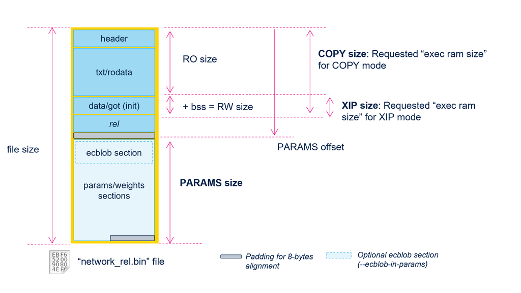

Layout of the runtime loadable module

The *“mempool c-descriptors”* table indicates the memory regions (part of the user memory-pools) and the flags which are considered by the ll_aton_reloc_install() function at runtime.

| flag | description |
| --- | --- |
| RELOC | Indicates a relocatable region, the address (dst=0) will be resolved at runtime during the installation process. |
| PARAM/ACTIV/MIXED | Indicates the type of contents: PARAM: params/weights only, ACTIV: activations only, MIXED: mixed |
| RCACHED/WCACHED | Indicates that a part of the memory region can be accessible through the NPU cache. RCACHED is associated with a RELOC.PARAM/read-only region |
| WRITE | Indicates that the memory region is a read-write memory region. |
| RESET | Indicates that the memory region can be cleared if the AI_RELOC_RT_LOAD_MODE_CLEAR option is used. |
| COPY | Indicates that the region is initialized/copied during the installation process. |
| UNUSED | Last entry in the *mempool c-descriptors* |

- The number *0* or *1* indicates the ID of the relocatable memory regions. Currently, only two regions are supported: *0* for a parameters/weights-only region in external flash and *1* for a read/write memory region in the external RAM.
- *foff* specifies the offset in the parameters/weights section to locate the associated memory initializer when requested.
- *dst* specifies the destination address. If not equal to zero, the address is an absolute address; otherwise, the region is a relocatable region.
- *size* specifies the size in bytes.

##### Example with a tiny model using only the internal NPU RAM for the activations and weights/params.

```bash
 +--------------------------+------------------------------+------+------------+-------+
 | name (addr)              | flags                        | foff | dst        | size  |
 +--------------------------+------------------------------+------+------------+-------+
 | AXISRAM6 (0x20004c64)    | 0x03020200 RESET.ACTIV.WRITE | 0    | 0x34350000 | 500   |
 | AXISRAM5 (0x20004c6d)    | 0x02030200 COPY.MIXED.WRITE  | 0    | 0x342e0000 | 33728 |
 | AXISRAM4 (0x20004c76)    | 0x03020200 RESET.ACTIV.WRITE | 0    | 0x34270000 | 40496 |
 | AXISRAM3 (0x20004c7f)    | 0x03020200 RESET.ACTIV.WRITE | 0    | 0x34200000 | 16000 |
 | <undefined> (0x00000000) | 0x00000000 UNUSED            | 0    | 0x00000000 | 0     |
 +--------------------------+------------------------------+------+------------+-------+
  Table: mempool c-descriptors (off=40000428, 5 entries, from RAM)
```

##### Example with a model using only the external RAM/FLASH (internal RAMs are not used)

During runtime in the installation process, the references related to xSPI1 and xSPI2 (relative address) are resolved to the external RAM address (reserved by the application) and the parameters/weights section (part of the installed relocatable module), respectively.

```bash
 +--------------------------+----------------------------------+------+------------+-------+
 | name (addr)              | flags                            | foff | dst        | size  |
 +--------------------------+----------------------------------+------+------------+-------+
 | xSPI1 (0x20004c62)       | 0x01020601 RELOC.ACTIV.1.WCACHED | 0    | 0x00000000 | 64496 |
 | xSPI2 (0x20004c68)       | 0x01010500 RELOC.PARAM.0.RCACHED | 0    | 0x00000000 | 32625 |
 | <undefined> (0x00000000) | 0x00000000 UNUSED                | 0    | 0x00000000 | 0     |
 +--------------------------+----------------------------------+------+------------+-------+
  Table: mempool c-descriptors (off=40001618, 3 entries, from RAM)
```

## Epoch controller consideration

There is **no functional limitation** on using the epoch controller with the runtime-loadable model. By default, the generated command streams (also called ecblobs) are stored as constants in the read-only data (rodata) section. However, as they reference addresses that are not known at generation time (i.e. weights/params buffers), a dedicated relocatable mechanism is implemented to patch the ecblobs during the initialization of the model. This mechanism requires an additional SRAM memory area in the uninitialized data (bss) section to copy the ecblobs before patching. The `-v 2` option of the ST Edge AI core CLI allows to report the detailed information about the rodata/bss sections related to the ecblob objects.

```bash
$ stedgeai generate -m <model-name>.tflite/onnx --target stm32n6 --st-neural-art <profile>@<usr_neural_art_reloc>.json --reloc -v 2
...
 +--------------------+--------+---------+-------+
 |        Name        |  bss   | ro data | reloc |
 +--------------------+--------+---------+-------+
 | _ec_blob_network_1 | 19,776 | 19,904  | r:ptr |
 |                    |        |         |       |
 |       total        | 19,776 | 19,904  |       |
 +--------------------+--------+---------+-------+
 Table: EC blob objects (1)
```

Consequently, to install a model, the size of the required executable RAM (XIP or COPY mode) is significantly more critical. Below tables illustrate the different required sizes according to the configuration.

- Weights/params are placed in the external flash (relative address)

| Configuration | XIP size | COPY size | params size | binary file size |
| --- | --- | --- | --- | --- |
| no EC | 3,344 | 32,544 | 25,713 | 58,552 |
| with EC | 20,416 | 53,640 | 22,065 | 55,984 |
| with EC + ecblob-in-params | 20,416 | 33,712 | 22,065 | 55,960 |

- Weights/params are placed in the internal RAM (fixed/absolute address).

| Configuration | XIP size | COPY size | params size | binary file size |
| --- | --- | --- | --- | --- |
| no EC | 1,888 | 32,600 | 25,713 | 66,496 |
| with EC | 632 | 33,088 | 22,065 | 55,832 |
| with EC + ecblob-in-params | 632 | 13,312 | 22,065 | 55,832 |

## Weights/params encryption consideration

If the model is generated to support the encrypted weights/params (with the NPU compiler option: `'--encrypt-weights'`), before to generate the relocatable binary model, the weights/params file (`network_atonbuf.xSPI2.raw` file) should be encrypted as for the non-relocatable model. This worklow is not integrated in the ST Edge AI core CLI. It is required to use directly the Python scripts (npu_driver.py srcript) to generate the relocatable binary model. The split option is also preferable to be able to fix the address of the weights/params in the flash memory, because the encryption is dependent of the storage location.

To use a model with the weights/params encrypted, the index/keys for the different bus interfaces should be set before to execute the model.

```c
...
  LL_ATON_RT_Reset_Network(&nn_instance);

  // Set bus interface keys -- used for encrypted inference only
  LL_Busif_SetKeys ( 0 , 0 , BUSIF_LSB_KEY , BUSIF_MSB_KEY );
  LL_Busif_SetKeys ( 0 , 1 , BUSIF_LSB_KEY , BUSIF_MSB_KEY );
  LL_Busif_SetKeys ( 1 , 0 , BUSIF_LSB_KEY , BUSIF_MSB_KEY );
  LL_Busif_SetKeys ( 1 , 1 , BUSIF_LSB_KEY , BUSIF_MSB_KEY );

  do {
    /* Execute first/next step of Cube.AI/ATON runtime */
    ll_aton_rt_ret = LL_ATON_RT_RunEpochBlock(&nn_instance);
    ...
```

## Format of the relocatable binary model

The following figure illustrates the layout of the generated relocatable binary model (`"network_rel.bin"` file). By default, the memory initializers (params/weights sections) are included in the image. If the split option is used, the params/weights sections are generated in a separated binary file (`"network_rel_params.bin"` file).

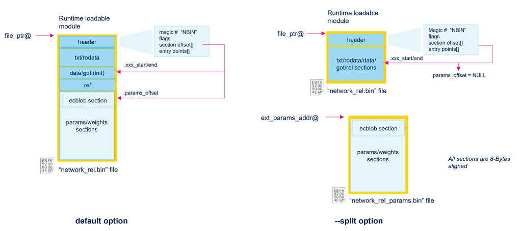

- If the epoch controller is enabled, the generated bitstreams are included in the rodata/data sections by defaut. The –ecblob-in-params option can be used to store the ecblob with the params section.
- The description of the params/weights sections is defined in the rodata section.
- When the split option is used, the address (`'ext_params_add'`) is passed and defined by the application when the ll_aton_reloc_install() function is called.

# Evaluating the RT loadable model ([STM32N6570-DK](https://www.st.com/en/evaluation-tools/stm32n6570-dk.html) board)

A ready-to-use environment for [STM32N6570-DK](https://www.st.com/en/evaluation-tools/stm32n6570-dk.html) board (DEV mode) is delivered in the ST Edge AI Core pack. It allows performing a classical validation workflow, validate command or through the stm_ai_runner Python package module. Note that a STM32CubeIDE environment must be installed.

Warning

Set the boot mode in development mode (BOOT1 switch position is 1-3, BOOT0 switch position does not matter). After the loading phase, the board must be **NOT** switched off or disconnected to be able to perform the validation.

After the generation of the relocatable binary model, the `st_load_and_run.py` Python script is used to flash the binary files at the fixed addresses, to load, and to run a built-in validation firmware. After these steps, a single inference is executed reporting the performance.

**[Details]** st_load_and_run.py script**

```bash
usage: st_load_and_run.py [-h] [--input [STR ...]] [--board STR]
                          [--address STR] [--mode STR] [--cube-ide-dir STR]
                          [--log [STR]] [--verbosity [{0,1,2}]] [--debug] [--no-color]

NPU Utility - ST Load and run (dev environment) v2.0

optional arguments:
  -h, --help            show this help message and exit
  --input [STR ...], -i [STR ...]
                        location of the binary files (default: build/network_rel.bin)
  --board STR           ST development board (default: stm32n6570-dk)
  --address STR         destination address - model(,params) (default: 0x71000000,0x71800000)
  --mode STR            firmware variants & mode: copy,xip[no-flash,no-overlay,no-run,usbc,ext]
  --cube-ide-dir STR    installation directory of STM32CubeIDE tools (ex. ~/ST/STM32CubeIDE_1.19.0/STM32CubeIDE)
  --log [STR]           log file
  --verbosity [{0,1,2}], -v [{0,1,2}]
                        set verbosity level
  --debug               enable internal log (DEBUG PURPOSE)
  --no-color            disable log color support
```

## Supported features/limitations

- Only the STM32N6570-DK board is supported. Destination addresses are fixed.
- **Multiple models** can be deployed.
  - By default, they share the same execution RAM memory region. The `no-overlay` mode can be used to force the creation of a dedicated memory region.
  - Execution of the models is always sequential, the activation regions are overlapped.
- –no-inputs/outputs-allocation` options are not supported.
- `copy` or `xip` mode can be selected. If the `xip` mode is not supported, `copy` mode is automatically used.
- the execution RAM region is located in the internal SRAM first, if more memory is requested, the external RAM is used.

## Deploy a model

```bash
$ $STEDGEAI_CORE_DIR/Utilities/windows/python $STEDGEAI_CORE_DIR/scripts/N6_reloc/st_load_and_run.py
   -i <output-directory-path>\network_rel.bin
```

```bash
NPU Utility - ST Load and run (dev environment) (version 2.0)
Creating date : ...

model info     : st_ai_output\network_rel.bin: size=55,832
                 cpuid=0xd22 c_name='network' 'Embedded ARM GCC' ll_aton=1.1.3.3
                 acts/params=57,087/22,065 xip/copy=632/13,312 ext_ram=0 split=False
                 secure=True
board          : 'stm32n6570-dk'
mode           : ['copy']

board info     : 'stm32n6570-dk' baudrate=921600 eflash_loader='MX66UW1G45G_STM32N6570-DK.stldr'
                   eflash[sec/pg]=64.0KB/4.0KB
                 exec_ram[int/ext]=655,360/4,194,304 ext_ram=28,311,552 addrs=0x70FFF000,0x71000000,0x71800000
use clang      : False
install mode   : 'copy'
total (1)      : overlay bin=65,536 xip=640 [copy=13,312] 'installed in int exec_ram' ext_ram=0
 flash@        : 0x71000000
 flash_params@ : 0x00000000

Resetting the board.
Flashing 'header (nb_entries=1)' at address 0x70FFF000 (size=20)..
Flashing 'st_ai_output\network_rel.bin' at address 0x71000000 (size=55832)..
Loading & start the validation application 'stm32n6570-dk-validation-reloc'..
Deployed model is started and ready to be used.
Executing the deployed model (desc=serial:921600)..
...
  Inference time per node
  -------------------------------------------------------------------------------------------------------------------
  c_id    m_id   type                dur (ms)       %    cumul  CPU cycles                      name
  -------------------------------------------------------------------------------------------------------------------
  0       -      epoch (EC)             0.210   96.6%    96.6%  [     896  166,877      573 ]   EpochBlock_1 -> 14
  1       -      epoch (SW)             0.007    3.4%   100.0%  [     110       40    5,704 ]   EpochBlock_15
  -------------------------------------------------------------------------------------------------------------------
  total                                 0.218                   [   1,006  166,917    6,277 ]
                                4592.41 inf/s                   [    0.6%    95.8%     3.6% ]
  -------------------------------------------------------------------------------------------------------------------
```

## Evaluate the model

Default validation workflow can be use to evaluate the deployed model.

```bash
$ stedgeai validate -m <quantize_model> --target stm32n6 --mode target -d serial:921600
```

```
...
Evaluation report (summary)
 -------------------------------------------------------------------------------------------------------------
 Output       acc    rmse         ...  std        nse        cos        tensor
 -------------------------------------------------------------------------------------------------------------
 X-cross #1   n.a.   0.007084151  ...  0.007081   0.999671   0.999910   10 x uint8(1x3087x6)
 -------------------------------------------------------------------------------------------------------------
```

## Deploy multiple models

Generate the models: `model1` and `model2`

```bash
stedgeai generate -m <model1> --target stm32n6 --st-neural-art test@$STEDGEAI_CORE_DIR/scripts/N6_reloc/test/neural_art_reloc.json -r -n model1

stedgeai generate -m <model2> --target stm32n6 --st-neural-art test@$STEDGEAI_CORE_DIR/scripts/N6_reloc/test/neural_art_reloc.json -r -n model2
```

Warning

Each deployed model must have its own c-name.

Deploy the models for evaluation

```bash
$ $STEDGEAI_CORE_DIR/Utilities/windows/python $STEDGEAI_CORE_DIR/scripts/N6_reloc/st_load_and_run.py
   -i <output-directory-path>\model1_rel.bin <output-directory-path>\model2_rel.bin
```

Evaluate the `model1` model

```bash
$ stedgeai validate -m <model12> --target stm32n6 --mode target -d serial:921600 -n model1
```